# Uncertainty Propagation in Model-Based Bioequivalence

## Parallel Design — A Simulation Study

Built with **Julia / Pumas** | One-Compartment Oral PK Model

Use arrow keys or swipe to navigate

# Agenda

1. **Motivation** — Why uncertainty matters
2. **Study Design** — PK model & trial setup
3. **Uncertainty Methods** — Fixed, VCOV, Bootstrap, SIR
4. **Simulation Engine** — Virtual BE trials
5. **Drug Variability** — %CV characterization
6. **Results** — Pass rates, power, Type I error
7. **Visualizations** — Heatmaps, CI plots
8. **Key Takeaways** — Regulatory implications

# 1

## Motivation & Background

# What is Model-Based Bioequivalence?

**Traditional BE**  
Conduct a clinical trial → apply NCA → compute 90% CI for GMR → check [0.80, 1.25]

**Model-Based BE (MBBE)**  
Fit a population PK model → simulate *virtual* BE trials → assess BE on simulated data

### Why MBBE?

- Leverage existing PK data (e.g., from Phase I/II)
- Explore design choices *in silico*
- Predict probability of BE success
- Reduce cost and risk of pivotal trials

# The Uncertainty Problem

Fit PK Model  
to Data

→

Parameter  
Estimates θ̂

→

Simulate  
Virtual Trials

→

Assess  
BE

**Problem:** θ̂ are *estimates* with uncertainty. If we treat them as fixed truth, our BE predictions may be **overconfident**.

**Question:** How do different methods of propagating parameter uncertainty affect **power** and **Type I error** of MBBE simulations?

# 2

## Study Design

# PK Model

### One-Compartment Oral Model

Depot' = −Ka · Depot  
Central' = Ka · Depot − (CL/V) · Central

C<sub>p</sub> = Central / V  
DV ~ Normal(C<sub>p</sub>, σ)

**Bioavailability control:**  
Test: F = tvbio | Reference: F = 1.0  
⇒ **AUC<sub>T</sub>/AUC<sub>R</sub> = tvbio** at population level

### Inter-Individual Variability

CL<sub>i</sub> = tvcl · e<sup>η<sub>1</sub></sup>  
V<sub>i</sub> = tvv · e<sup>η<sub>2</sub></sup>  
Ka<sub>i</sub> = tvka · e<sup>η<sub>3</sub></sup>

η ~ MVN(0, Ω)  
Ω = diag(0.09, 0.09, 0.09)

√0.09 = 0.30 ⇒ **~30% CV** on each parameter

# True (Ground Truth) Parameters

| Parameter | Value | Description |
| --- | --- | --- |
| tvcl | 5.0 | Typical clearance (L/hr) |
| tvv | 50.0 | Typical volume (L) |
| tvka | 1.2 | Typical absorption rate (1/hr) |
| tvbio | 1.0 | True T/R ratio (true BE) |
| Ω | diag(0.09, 0.09, 0.09) | IIV (~30% CV) |
| σ | 0.2 | Additive residual error |

The reference trial is simulated with **tvbio = 1.0** (true bioequivalence), then the model is re-estimated using FOCE to obtain θ̂.

# Parallel-Design BE Trial

**Design:** Two independent groups

- Group 1: receives **Reference (R)**
- Group 2: receives **Test (T)**

**Dose:** 100 mg oral, single dose  
**Sampling:** 0–72 hours (hourly)  
**Sample sizes explored:** 12, 24, 30, 40, 50, 60, 80 per arm

### BE Acceptance Criterion (TOST)

0.80 ≤ 90% CI of GMR ≤ 1.25

Both AUC **and** C<sub>max</sub> must pass for overall BE.

### T/R Ratios Explored

0.7 0.9 1.0 1.1 1.3

0.7 & 1.3 = outside BE limits (Type I error)  
0.9, 1.0, 1.1 = within BE limits (Power)

# 3

## Uncertainty Propagation Methods

# Four Methods Compared

### 1 Fixed (No Uncertainty)

Use point estimates θ̂ directly.  
No variability in parameters across simulations.

**Cost:** None **Baseline comparator**

### 2 VCOV (Asymptotic Normal)

Sample from multivariate normal using the variance-covariance matrix from FOCE fit.

**Cost:** Minimal (matrix inversion at MLE)

### 3 Bootstrap

Resample data → re-fit model 100 times → sample from bootstrap covariance.

**Cost:** High (100 re-fits)

### 4 SIR (Sampling Importance Resampling)

Evaluate likelihood at many candidates → resample by importance weights.

**Cost:** Moderate (no re-fitting)

# How Parameters Are Sampled

**All methods use the same sampling helper** (for VCOV, Bootstrap, SIR):

1. Form μ = log(θ̂) (log of all point estimates)  
2. Draw θ* ~ exp( MVN(μ, V) ) (sample on log scale, exponentiate back)

**Why log scale?**  
All PK parameters (CL, V, Ka, Ω, σ) are strictly positive. Sampling on the log scale and exponentiating back guarantees positivity.

**Each method differs in V:**  
• VCOV: V = asymptotic covariance  
• Bootstrap: V = bootstrap covariance  
• SIR: V = SIR-derived covariance  
All generate **200 parameter sets**.

# 4

## Virtual BE Simulation Engine

# Simulation Workflow

For each (method × sample size × T/R ratio) combination:

Draw θ*  
from uncertainty  
samples

→

Override tvbio  
with target  
T/R ratio

→

Simulate  
full BE  
trial

→

Run NCA  
& compute  
90% CI

→

Record  
Pass /  
Fail

**Simulation grid:** 4 methods × 7 sample sizes × 5 T/R ratios × **200 simulations** = 28,000 virtual trials

**Key mechanism:** In Fixed method, θ* = θ̂ every time. In uncertainty methods, each simulation draws a *different* θ*, propagating estimation uncertainty into the BE assessment.

# Metrics

## Power

**Definition:** BE pass rate when the true T/R ratio is *within* the BE limits.  
Measured at T/R ∈ {0.9, 1.0, 1.1}  
**Goal:** Should be high (≥ 80%)

## Type I Error

**Definition:** BE pass rate when the true T/R ratio is *outside* the BE limits.  
Measured at T/R ∈ {0.7, 1.3}  
**Goal:** Should be controlled (≤ 5%)

# 5

## Drug Variability Characterization

# Between-Subject %CV

Estimated via NCA from 100 simulated parallel-design trials (60 subjects/arm, T/R = 1.0)

24.4%

AUC %CV

20.7%

C<sub>max</sub> %CV

This represents a drug with **moderate variability** — typical of many orally administered drugs. Not a highly variable drug (HVD), where %CV > 30%.

# 6

## Results & Visualizations

## Uncertainty Methods Elevate Tail Pass Rates Above the 5% Alpha Level

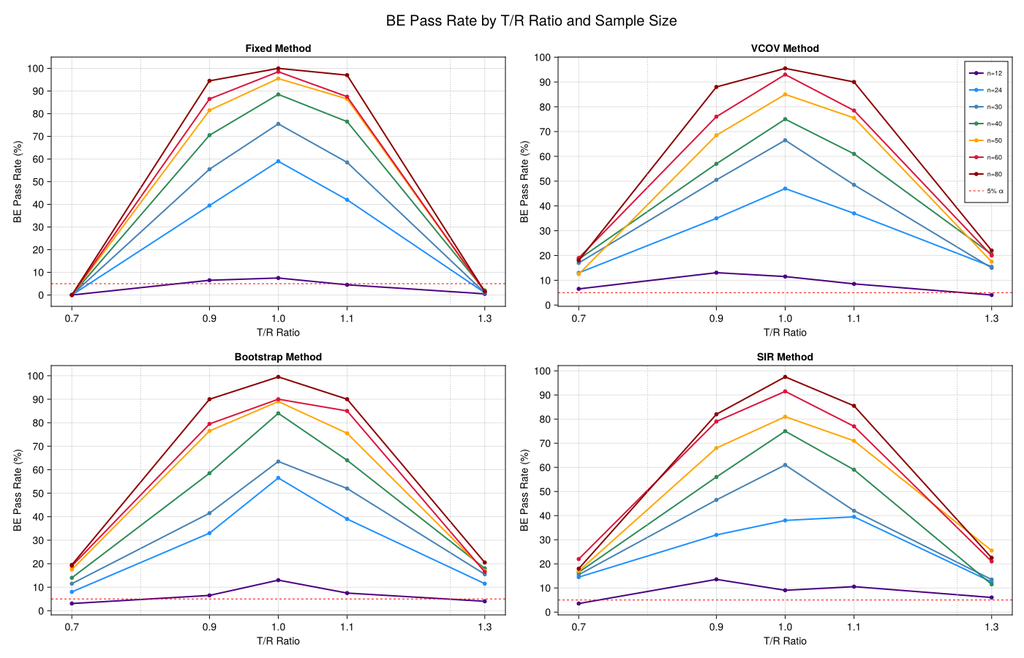

**Fixed method:** Clean inverted-U peaking at T/R=1.0. Tails at 0.7 & 1.3 near 0% ✓

**Uncertainty methods:** Tails elevated well above the 5% alpha line (red dashed) ✗

| T/R Ratio | Fixed | VCOV | Bootstrap | SIR |
| --- | --- | --- | --- | --- |
| 0.7 | 0.0 | 13.0 | 8.0 | 14.5 |
| 0.9 | 39.5 | 35.0 | 33.0 | 32.0 |
| 1.0 | 59.0 | 47.0 | 56.5 | 38.0 |
| 1.1 | 42.0 | 37.0 | 39.0 | 39.5 |
| 1.3 | 1.0 | 15.5 | 11.5 | 12.5 |

With 24 subjects/arm, Fixed has ≤1% Type I error vs 8–15% for uncertainty methods. Power at T/R=1.0 is modest (38–59%) for all methods.

## At n=30: Fixed Reaches 75% Power but Uncertainty Methods Stay Below 67%

| T/R Ratio | Fixed | VCOV | Bootstrap | SIR |
| --- | --- | --- | --- | --- |
| 0.7 | 0.0 | 17.0 | 11.5 | 15.5 |
| 0.9 | 55.5 | 50.5 | 41.5 | 46.5 |
| 1.0 | 75.5 | 66.5 | 63.5 | 61.0 |
| 1.1 | 58.5 | 48.5 | 52.0 | 42.0 |
| 1.3 | 1.0 | 15.0 | 15.5 | 13.5 |

At n=30, Fixed reaches 75.5% power (T/R=1.0) with controlled error; uncertainty methods show 5–15 point power penalty and 11–17% Type I error.

## At n=60: Near-Perfect Fixed Power (98.5%) but Uncertainty Error Reaches 22%

| T/R Ratio | Fixed | VCOV | Bootstrap | SIR |
| --- | --- | --- | --- | --- |
| 0.7 | 0.0 | 19.0 | 19.0 | 22.0 |
| 0.9 | 86.5 | 76.0 | 79.5 | 79.0 |
| 1.0 | 98.5 | 93.0 | 90.0 | 91.5 |
| 1.1 | 87.5 | 78.5 | 85.0 | 77.0 |
| 1.3 | 1.5 | 20.0 | 16.5 | 21.0 |

Even with 60/arm, uncertainty methods show 16–22% Type I error — far above 5%. The problem *worsens* with more subjects.

## Uncertainty Propagation Blurs the BE/Non-BE Decision Boundary

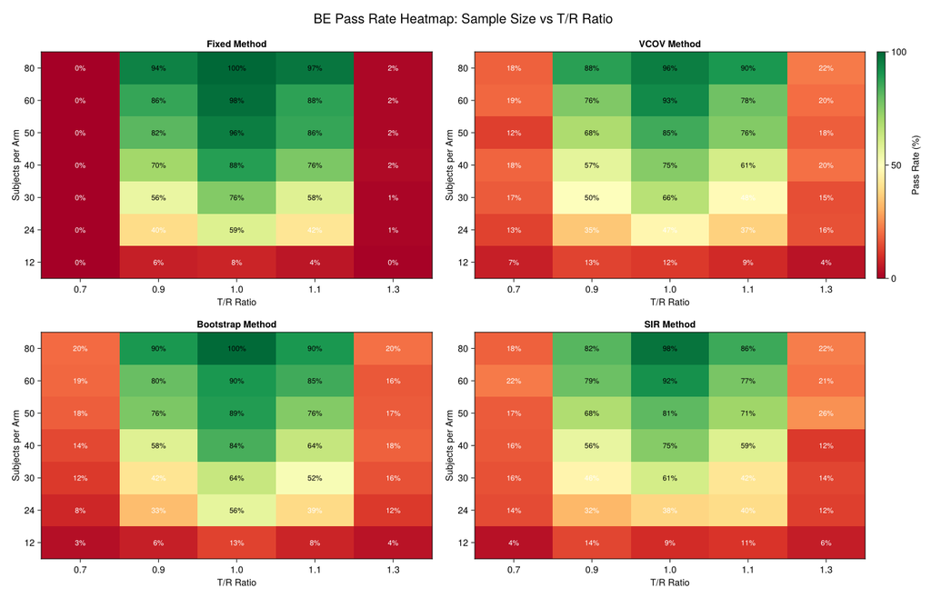

**Fixed:** Crisp red (fail) ↔ green (pass) separation. Clean decision boundary.

**Uncertainty:** Yellow-orange "fuzzy" zone at T/R = 0.7 & 1.3 — parameter uncertainty erodes the boundary.

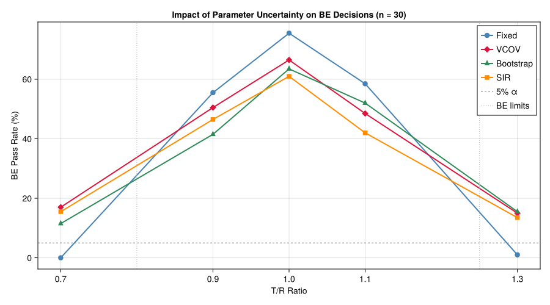

At n=30, all four methods produce similar pass rates at T/R = 1.0 (60–76%). The critical divergence is at T/R = 0.7 and 1.3: Fixed stays near 0% while uncertainty methods reach 11–17%.

## Uncertainty Costs 10–20 Extra Subjects/Arm to Reach 80% Power

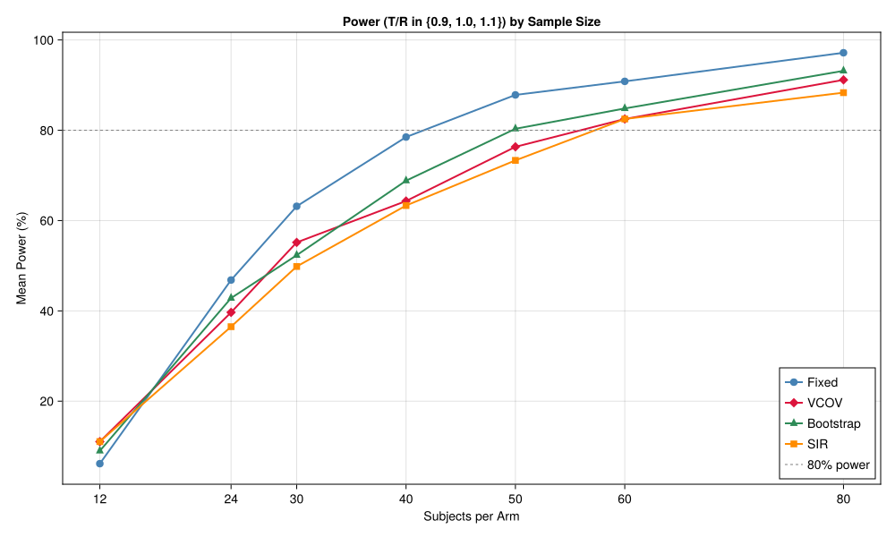

| Method | Color | n for 80% |
| --- | --- | --- |
| Fixed | ● steelblue | ~40/arm |
| VCOV | ◆ crimson | ~60/arm |
| Bootstrap | ▲ seagreen | ~50/arm |
| SIR | ■ darkorange | ~60/arm |

**The "uncertainty tax":** 10–20 extra subjects per arm to achieve the same power level.

## 50–60 Subjects/Arm Needed for 80% Power with Uncertainty Methods

Mean power (%) across T/R ∈ {0.9, 1.0, 1.1}

| n/arm | Fixed | VCOV | Bootstrap | SIR |
| --- | --- | --- | --- | --- |
| 12 | 6.2 | 11.0 | 9.0 | 11.1 |
| 24 | 46.8 | 39.7 | 42.8 | 36.5 |
| 30 | 63.2 | 55.2 | 52.3 | 49.8 |
| 40 | 78.5 | 64.3 | 68.8 | 63.3 |
| 50 | 87.8 | 76.3 | 80.3 | 73.3 |
| 60 | 90.8 | 82.5 | 84.8 | 82.5 |
| 80 | 97.2 | 91.2 | 93.2 | 88.3 |

## Type I Error Rises with Sample Size for Uncertainty Methods — A Paradox

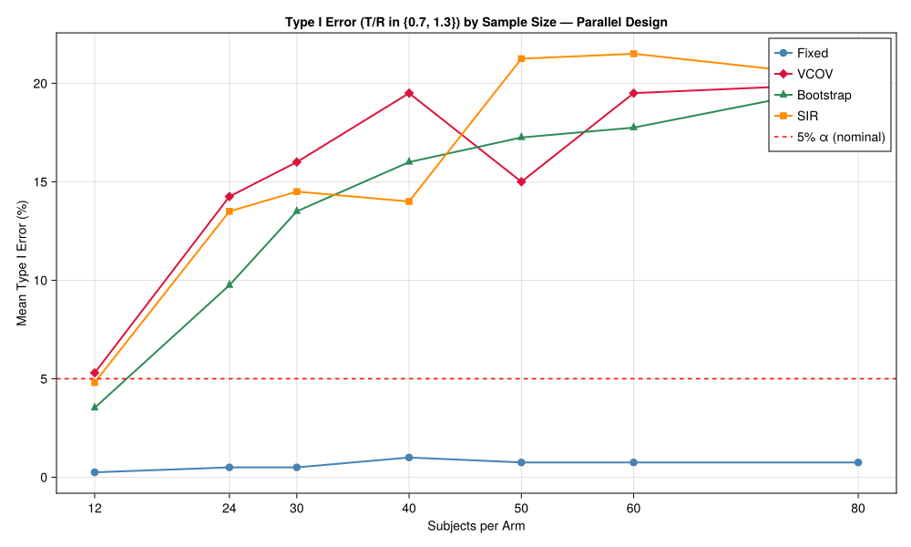

**Critical finding:** All uncertainty methods inflate Type I error to **15–21%** (vs nominal 5%). Fixed stays below 1%.

**Counterintuitive:** Type I error *increases* with sample size because larger trials have more powerful TOST tests that more easily declare BE when parameter draws are favorable.

## Type I Error Plateaus at 20% for All Uncertainty Methods by n=80

Mean Type I error (%) across T/R ∈ {0.7, 1.3}

| n/arm | Fixed | VCOV | Bootstrap | SIR |
| --- | --- | --- | --- | --- |
| 12 | 0.25 | 5.3 | 3.5 | 4.8 |
| 24 | 0.5 | 14.3 | 9.8 | 13.5 |
| 30 | 0.5 | 16.0 | 13.5 | 14.5 |
| 40 | 1.0 | 19.5 | 16.0 | 14.0 |
| 50 | 0.75 | 15.0 | 17.3 | 21.3 |
| 60 | 0.75 | 19.5 | 17.8 | 21.5 |
| 80 | 0.75 | 20.0 | 20.0 | 20.3 |

All three uncertainty methods converge to ~20% Type I error at large n. Fixed stays consistently below 1% — the fundamental asymmetry.

# Why Is Type I Error Inflated?

True T/R = 0.7  
(NOT bioequivalent)

→

Draw θ*  
from uncertainty  
distribution

→

Some draws shift  
PK profiles enough  
to mimic BE

→

False positive  
BE conclusion

**Mechanism:** Uncertain parameters occasionally produce simulated trials where the *apparent* T/R ratio shifts toward 1.0, even though the *true* T/R is 0.7 or 1.3.

**Counterintuitive:** Type I error *increases* with sample size for uncertainty methods, because larger trials have more powerful TOST tests that are more likely to declare BE when parameters are favorably drawn.

This is a **serious regulatory concern** — uncertainty propagation as implemented here could lead to approving non-bioequivalent products.

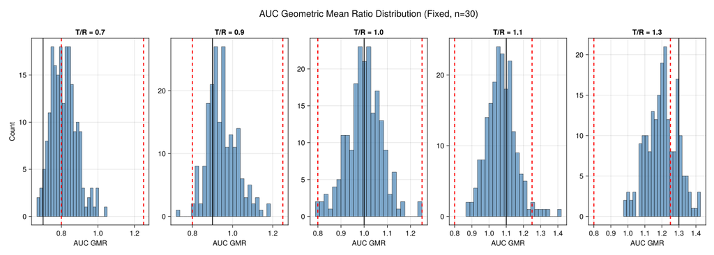

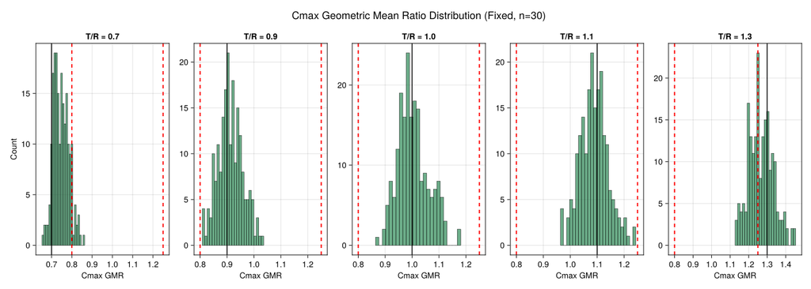

## 90% CI Bounds at T/R = 0.7 and 1.3 Frequently Cross BE Limits

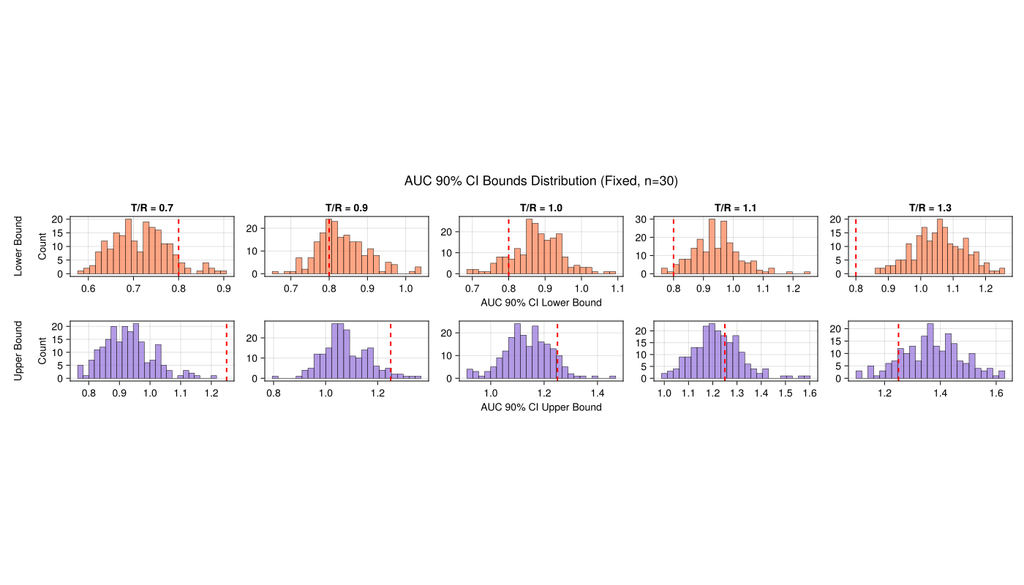

## Larger Samples Produce Tighter CIs That Fit Within [0.80, 1.25]

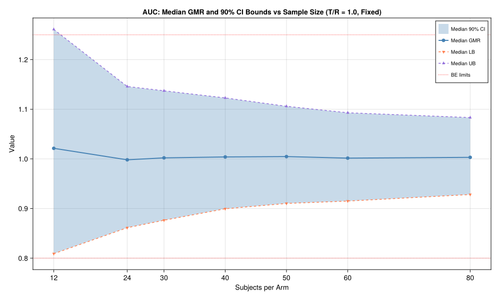

| n/arm | CI Width | Fits [0.80, 1.25]? |
| --- | --- | --- |
| 12 | Very wide | Often no |
| 24 | Wide | Sometimes |
| 40 | Moderate | Usually |
| 60 | Narrow | Almost always |
| 80 | Very narrow | Yes |

The fundamental tradeoff: larger n → tighter CI → higher probability of fitting within BE limits when the true ratio is near 1.0.

# 7

## Key Takeaways

# Summary of Findings

**1. Fixed method**  
Highest power, well-controlled Type I error (<1%). But **overconfident** — ignores real-world uncertainty.

**2. Power penalty**  
Uncertainty propagation costs **5–15 percentage points** of power, requiring 10–20 extra subjects per arm.

**3. Inflated Type I error**  
All uncertainty methods show **15–21% Type I error** at larger sample sizes — far above the 5% nominal level.

**4. Methods are similar**  
VCOV, Bootstrap, and SIR yield broadly comparable results. VCOV is the cheapest computationally.

# The Uncertainty Dilemma

Ignore

uncertainty  
**Pro:** Controlled Type I error  
**Con:** Optimistic power estimates

Propagate

uncertainty  
**Pro:** More realistic simulations  
**Con:** Inflated Type I error (up to 21%)

**Implication:** Neither approach is fully satisfactory. The field needs methods that propagate uncertainty while maintaining Type I error control — potentially through calibration, restricted sampling, or alternative uncertainty frameworks.

# Regulatory Implications

**Type I error inflation is the most critical finding.**  
If an uncertainty-propagated MBBE simulation suggests a product is bioequivalent, there is up to a ~20% chance this conclusion is *wrong* when the true T/R ratio is outside [0.80, 1.25].

### Recommendations

- **For sponsors:** Report both Fixed and uncertainty-propagated results to bracket the true operating characteristics
- **For regulators:** Be cautious interpreting MBBE results with uncertainty propagation — consider requiring calibration studies
- **For methodologists:** Develop approaches that decouple uncertainty propagation from Type I error inflation
- **Sample sizing:** Plan for **50–60 subjects per arm** in parallel designs to ensure adequate power even with uncertainty

# Technical Summary

| Aspect | Detail |
| --- | --- |
| Software | Julia + Pumas + Bioequivalence + CairoMakie |
| PK Model | 1-compartment oral, first-order absorption, additive error |
| Trial Design | Parallel (two independent groups) |
| Estimation | FOCE (First-Order Conditional Estimation) |
| Uncertainty Methods | Fixed, VCOV (asymptotic), Bootstrap (100 resamples), SIR (200/100) |
| BE Criterion | TOST: 90% CI of GMR within [0.80, 1.25] for both AUC and C<sub>max</sub> |
| Sample Sizes | 12, 24, 30, 40, 50, 60, 80 subjects per arm |
| T/R Ratios | 0.7, 0.9, 1.0, 1.1, 1.3 |
| Simulations | 200 per cell × 140 cells = 28,000 virtual trials |
| Drug Variability | AUC %CV = 24.4%, C<sub>max</sub> %CV = 20.7% (moderate) |

# Thank You

## Uncertainty Propagation in MBBE — Parallel Design

Full analysis and interactive figures available in  
`mbbe-uncertainity-v2-parallel.html`

Built with Julia / Pumas | Quarto | Reveal.js